# An introduction to cutpointr

Christian Thiele

2025-06-13

**cutpointr** is an R package for tidy calculation of “optimal” cutpoints. It supports several methods for calculating cutpoints and includes several metrics that can be maximized or minimized by selecting a cutpoint. Some of these methods are designed to be more robust than the simple empirical optimization of a metric. Additionally, **cutpointr** can automatically bootstrap the variability of the optimal cutpoints and return out-of-bag estimates of various performance metrics.

## Installation

You can install **cutpointr** from CRAN using the menu in RStudio or simply:

```r
install.packages("cutpointr")
```

## Example

For example, the optimal cutpoint for the included data set is 2 when maximizing the sum of sensitivity and specificity.

```r
library(cutpointr)
data(suicide)
head(suicide)
```

```
##   age gender dsi suicide
## 1  29 female   1      no
## 2  26   male   0      no
## 3  26 female   0      no
## 4  27 female   0      no
## 5  28 female   0      no
## 6  53   male   2      no
```

```r
cp <- cutpointr(suicide, dsi, suicide,
                method = maximize_metric, metric = sum_sens_spec)
```

```
## Assuming the positive class is yes
```

```
## Assuming the positive class has higher x values
```

```r
summary(cp)
```

```
## Method: maximize_metric
## Predictor: dsi
## Outcome: suicide
## Direction: >=
##
##     AUC   n n_pos n_neg
##  0.9238 532    36   496
##
##  optimal_cutpoint sum_sens_spec    acc sensitivity specificity tp fn fp  tn
##                 2        1.7518 0.8647      0.8889      0.8629 32  4 68 428
##
## Predictor summary:
##     Data Min.   5% 1st Qu. Median      Mean 3rd Qu.  95% Max.       SD NAs
##  Overall    0 0.00       0      0 0.9210526       1 5.00   11 1.852714   0
##       no    0 0.00       0      0 0.6330645       0 4.00   10 1.412225   0
##      yes    0 0.75       4      5 4.8888889       6 9.25   11 2.549821   0
```

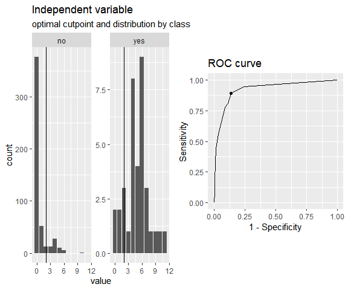

```r
plot(cp)
```

When considering the optimality of a cutpoint, we can only make a judgement based on the sample at hand. Thus, the estimated cutpoint may not be optimal within the population or on unseen data, which is why we sometimes put the “optimal” in quotation marks.

`cutpointr` makes assumptions about the direction of the dependency between `class` and `x`, if `direction` and / or `pos_class` or `neg_class` are not specified. The same result as above can be achieved by manually defining `direction` and the positive / negative classes which is slightly faster, since the classes and direction don’t have to be determined:

```r
opt_cut <- cutpointr(suicide, dsi, suicide, direction = ">=", pos_class = "yes",
                     neg_class = "no", method = maximize_metric, metric = youden)
```

`opt_cut` is a data frame that returns the input data and the ROC curve (and optionally the bootstrap results) in a nested tibble. Methods for summarizing and plotting the data and results are included (e.g. `summary`, `plot`, `plot_roc`, `plot_metric`)

To inspect the optimization, the function of metric values per cutpoint can be plotted using `plot_metric`, if an optimization function was used that returns a metric column in the `roc_curve` column. For example, the `maximize_metric` and `minimize_metric` functions do so:

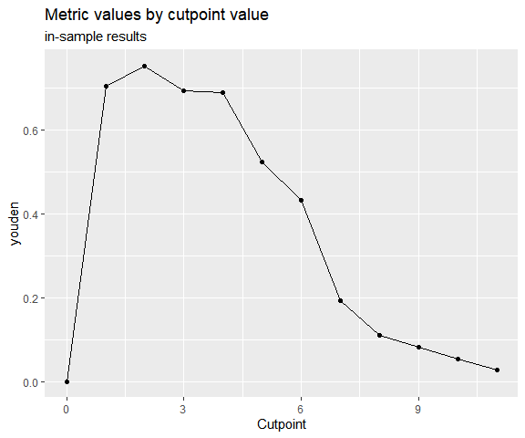

```r
plot_metric(opt_cut)
```

Predictions for new data can be made using `predict`:

```r
predict(opt_cut, newdata = data.frame(dsi = 0:5))
```

```
## [1] "no"  "no"  "yes" "yes" "yes" "yes"
```

## Features

- Calculation of optimal cutpoints in binary classification tasks
- Tidy output, integrates well with functions from the tidyverse
- Functions for plotting ROC curves, metric distributions and more
- Bootstrapping for simulating the cutpoint variability and for obtaining out-of-bag estimates of various metrics (as a form of internal validation) with optional parallelisation
- Multiple methods for calculating cutpoints
- Multiple metrics can be chosen for maximization / minimization
- Tidyeval

# Calculating cutpoints

## Method functions for cutpoint estimation

The included methods for calculating cutpoints are:

- `maximize_metric`: Maximize the metric function
- `minimize_metric`: Minimize the metric function
- `maximize_loess_metric`: Maximize the metric function after LOESS smoothing
- `minimize_loess_metric`: Minimize the metric function after LOESS smoothing
- `maximize_gam_metric`: Maximize the metric function after smoothing via Generalized Additive Models
- `minimize_gam_metric`: Minimize the metric function after smoothing via Generalized Additive Models
- `maximize_boot_metric`: Bootstrap the optimal cutpoint when maximizing a metric
- `minimize_boot_metric`: Bootstrap the optimal cutpoint when minimizing a metric
- `oc_manual`: Specify the cutoff value manually
- `oc_mean`: Use the sample mean as the “optimal” cutpoint
- `oc_median`: Use the sample median as the “optimal” cutpoint
- `oc_youden_kernel`: Maximize the Youden-Index after kernel smoothing the distributions of the two classes
- `oc_youden_normal`: Maximize the Youden-Index parametrically assuming normally distributed data in both classes

## Metric functions

The included metrics to be used with the minimization and maximization methods are:

- `accuracy`: Fraction correctly classified
- `abs_d_sens_spec`: The absolute difference of sensitivity and specificity
- `abs_d_ppv_npv`: The absolute difference between positive predictive value (PPV) and negative predictive value (NPV)
- `roc01`: Distance to the point (0,1) on ROC space
- `cohens_kappa`: Cohen’s Kappa
- `sum_sens_spec`: sensitivity + specificity
- `sum_ppv_npv`: The sum of positive predictive value (PPV) and negative predictive value (NPV)
- `prod_sens_spec`: sensitivity * specificity
- `prod_ppv_npv`: The product of positive predictive value (PPV) and negative predictive value (NPV)
- `youden`: Youden- or J-Index = sensitivity + specificity - 1
- `odds_ratio`: (Diagnostic) odds ratio
- `risk_ratio`: risk ratio (relative risk)
- `p_chisquared`: The p-value of a chi-squared test on the confusion matrix
- `cost_misclassification`: The sum of the misclassification cost of false positives and false negatives. Additional arguments: cost_fp, cost_fn
- `total_utility`: The total utility of true / false positives / negatives. Additional arguments: utility_tp, utility_tn, cost_fp, cost_fn
- `F1_score`: The F1-score (2 * TP) / (2 * TP + FP + FN)
- `metric_constrain`: Maximize a selected metric given a minimal value of another selected metric
- `sens_constrain`: Maximize sensitivity given a minimal value of specificity
- `spec_constrain`: Maximize specificity given a minimal value of sensitivity
- `acc_constrain`: Maximize accuracy given a minimal value of sensitivity

Furthermore, the following functions are included which can be used as metric functions but are more useful for plotting purposes, for example in `plot_cutpointr`, or for defining new metric functions: `tp`, `fp`, `tn`, `fn`, `tpr`, `fpr`, `tnr`, `fnr`, `false_omission_rate`, `false_discovery_rate`, `ppv`, `npv`, `precision`, `recall`, `sensitivity`, and `specificity`.

The inputs to the arguments `method` and `metric` are functions so that user-defined functions can easily be supplied instead of the built-in ones.

## Separate subgroups and bootstrapping

Cutpoints can be separately estimated on subgroups that are defined by a third variable, `gender` in this case. Additionally, if `boot_runs` is larger zero, `cutpointr` will carry out the usual cutpoint calculation on the full sample, just as before, and additionally on `boot_runs` bootstrap samples. This offers a way of gauging the out-of-sample performance of the cutpoint estimation method. If a subgroup is given, the bootstrapping is carried out separately for every subgroup which is also reflected in the plots and output.

```r
set.seed(12)
opt_cut_b <- cutpointr(suicide, dsi, suicide, boot_runs = 1000)
```

```r
opt_cut_b
```

```
## # A tibble: 1 × 16
##   direction optimal_cutpoint method          sum_sens_spec      acc sensitivity
##   <chr>                <dbl> <chr>                   <dbl>    <dbl>       <dbl>
## 1 >=                       2 maximize_metric       1.75179 0.864662    0.888889
##   specificity      AUC pos_class neg_class prevalence outcome predictor
##         <dbl>    <dbl> <fct>     <fct>          <dbl> <chr>   <chr>
## 1    0.862903 0.923779 yes       no         0.0676692 suicide dsi
##   data               roc_curve            boot
##   <list>             <list>               <list>
## 1 <tibble [532 × 2]> <rc_ctpnt [13 × 10]> <tibble [1,000 × 23]>
```

The returned object has the additional column `boot` which is a nested tibble that includes the cutpoints per bootstrap sample along with the metric calculated using the function in `metric` and various default metrics. The metrics are suffixed by `_b` to indicate in-bag results or `_oob` to indicate out-of-bag results:

```r
opt_cut_b$boot
```

```
## [[1]]
## # A tibble: 1,000 × 23
##    optimal_cutpoint AUC_b AUC_oob sum_sens_spec_b sum_sens_spec_oob acc_b
##               <dbl> <dbl>   <dbl>           <dbl>             <dbl> <dbl>
##  1                2 0.957   0.884            1.80              1.71 0.874
##  2                1 0.918   0.935            1.70              1.70 0.752
##  3                2 0.920   0.946            1.79              1.73 0.874
##  4                2 0.940   0.962            1.82              1.76 0.893
##  5                2 0.849   0.96             1.66              1.76 0.848
##  6                4 0.926   0.927            1.80              1.51 0.925
##  7                2 0.927   0.919            1.74              1.78 0.885
##  8                2 0.958   0.882            1.82              1.67 0.863
##  9                4 0.911   0.923            1.80              1.53 0.914
## 10                1 0.871   0.975            1.62              1.80 0.737
## # ℹ 990 more rows
## # ℹ 17 more variables: acc_oob <dbl>, sensitivity_b <dbl>,
## #   sensitivity_oob <dbl>, specificity_b <dbl>, specificity_oob <dbl>,
## #   cohens_kappa_b <dbl>, cohens_kappa_oob <dbl>, TP_b <dbl>, FP_b <dbl>,
## #   TN_b <int>, FN_b <int>, TP_oob <dbl>, FP_oob <dbl>, TN_oob <int>,
## #   FN_oob <int>, roc_curve_b <list>, roc_curve_oob <list>
```

The summary and plots include additional elements that summarize or display the bootstrap results:

```r
summary(opt_cut_b)
```

```
## Method: maximize_metric
## Predictor: dsi
## Outcome: suicide
## Direction: >=
## Nr. of bootstraps: 1000
##
##     AUC   n n_pos n_neg
##  0.9238 532    36   496
##
##  optimal_cutpoint sum_sens_spec    acc sensitivity specificity tp fn fp  tn
##                 2        1.7518 0.8647      0.8889      0.8629 32  4 68 428
##
## Predictor summary:
##     Data Min.   5% 1st Qu. Median      Mean 3rd Qu.  95% Max.       SD NAs
##  Overall    0 0.00       0      0 0.9210526       1 5.00   11 1.852714   0
##       no    0 0.00       0      0 0.6330645       0 4.00   10 1.412225   0
##      yes    0 0.75       4      5 4.8888889       6 9.25   11 2.549821   0
##
## Bootstrap summary:
##           Variable Min.   5% 1st Qu. Median Mean 3rd Qu.  95% Max.   SD NAs
##   optimal_cutpoint 1.00 1.00    2.00   2.00 2.12    2.00 4.00 4.00 0.72   0
##              AUC_b 0.83 0.88    0.91   0.93 0.92    0.94 0.96 0.98 0.02   0
##            AUC_oob 0.82 0.86    0.90   0.92 0.92    0.95 0.97 1.00 0.03   0
##    sum_sens_spec_b 1.57 1.67    1.72   1.76 1.76    1.80 1.84 1.89 0.05   0
##  sum_sens_spec_oob 1.37 1.56    1.66   1.72 1.71    1.78 1.86 1.90 0.09   0
##              acc_b 0.73 0.77    0.85   0.87 0.86    0.88 0.91 0.94 0.04   0
##            acc_oob 0.72 0.77    0.85   0.86 0.86    0.88 0.90 0.93 0.04   0
##      sensitivity_b 0.72 0.81    0.86   0.90 0.90    0.94 0.98 1.00 0.05   0
##    sensitivity_oob 0.44 0.67    0.80   0.87 0.86    0.93 1.00 1.00 0.10   0
##      specificity_b 0.72 0.76    0.85   0.86 0.86    0.88 0.91 0.94 0.04   0
##    specificity_oob 0.69 0.76    0.84   0.86 0.86    0.88 0.91 0.94 0.04   0
##     cohens_kappa_b 0.16 0.27    0.37   0.42 0.41    0.46 0.52 0.66 0.07   0
##   cohens_kappa_oob 0.15 0.25    0.34   0.39 0.39    0.44 0.51 0.62 0.08   0
```

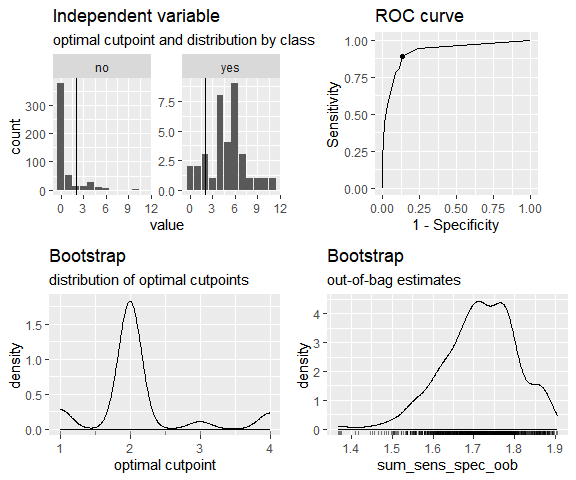

```r
plot(opt_cut_b)
```

### Parallelized bootstrapping

Using `foreach` and `doRNG` the bootstrapping can be parallelized easily. The **doRNG** package is being used to make the bootstrap sampling reproducible.

```r
library(doParallel)
cl <- makeCluster(2) # 2 cores
registerDoParallel(cl)
registerDoRNG(12) # Reproducible parallel loops using doRNG
opt_cut <- cutpointr(suicide, dsi, suicide, gender, pos_class = "yes",
                     direction = ">=", boot_runs = 1000, allowParallel = TRUE)
stopCluster(cl)
opt_cut
```

# Additional features

## Finding all cutpoints with acceptable performance

```r
library(tidyr)
library(dplyr)
opt_cut <- cutpointr(suicide, dsi, suicide, metric = sum_sens_spec,
                     tol_metric = 0.05, break_ties = c)
```

```
## Assuming the positive class is yes
```

```
## Assuming the positive class has higher x values
```

```
## Multiple optimal cutpoints found, applying break_ties.
```

```r
opt_cut |>
    select(optimal_cutpoint, sum_sens_spec) |>
    unnest(cols = c(optimal_cutpoint, sum_sens_spec))
```

```
## # A tibble: 2 × 2
##   optimal_cutpoint sum_sens_spec
##              <dbl>         <dbl>
## 1                2          1.75
## 2                1          1.70
```

## Manual and mean / median cutpoints

Using the `oc_manual` function the optimal cutpoint will not be determined based on, for example, a metric but is instead set manually using the `cutpoint` argument. This is useful for supplying and evaluating cutpoints that were found in the literature or in other external sources.

The `oc_manual` function could also be used to set the cutpoint to the sample mean using `cutpoint = mean(data$x)`. However, this may introduce bias into the bootstrap validation procedure, since the actual mean of the population is not known and thus the mean to be used as the cutpoint should be automatically determined in every resample. To do so, the `oc_mean` and `oc_median` functions can be used.

```r
set.seed(100)
opt_cut_manual <- cutpointr(suicide, dsi, suicide, method = oc_manual,
                       cutpoint = mean(suicide$dsi), boot_runs = 1000)
set.seed(100)
opt_cut_mean <- cutpointr(suicide, dsi, suicide, method = oc_mean, boot_runs = 1000)
```

## Nonstandard evaluation via tidyeval

The arguments to `cutpointr` do not need to be enclosed in quotes. This is possible thanks to nonstandard evaluation of the arguments, which are evaluated on `data`.

Functions that use nonstandard evaluation are often not suitable for programming with. The use of nonstandard evaluation may lead to scoping problems and subsequent obvious as well as possibly subtle errors. **cutpointr** uses tidyeval internally and accordingly the same rules as for programming with `dplyr` apply. Arguments can be unquoted with `!!`:

```r
myvar <- "dsi"
cutpointr(suicide, !!myvar, suicide)
```

## Midpoints

So far - which is the default in `cutpointr` - we have considered all unique values of the predictor as possible cutpoints. An alternative could be to use a sequence of equidistant values instead, for example in the case of the `suicide` data all integers in $[0, 10]$. However, with very sparse data and small intervals between the candidate cutpoints (i.e. a ‘dense’ sequence like `seq(0, 10, by = 0.01)`) this leads to the uninformative evaluation of large ranges of cutpoints that all result in the same metric value. A more elegant alternative, not only for the case of sparse data, that is supported by **cutpointr** is the use of a mean value of the optimal cutpoint and the next highest (if `direction = ">="`) or the next lowest (if `direction = "<="`) predictor value in the data. The result is an optimal cutpoint that is equal to the cutpoint that would be obtained using an infinitely dense sequence of candidate cutpoints and is thus usually more efficient computationally.

Assume the following small data set:

```r
dat <- data.frame(outcome = c("neg", "neg", "neg", "pos", "pos", "pos", "pos"),
                  pred    = c(1, 2, 3, 8, 11, 11, 12))
```

Since the distance of the optimal cutpoint (8) to the next lowest observation (3) is rather large we arrive at a range of possible cutpoints that all maximize the metric. In the case of this kind of sparseness it might for example be desirable to classify a new observation with a predictor value of 4 as belonging to the negative class. If `use_midpoints` is set to `TRUE`, the mean of the optimal cutpoint and the next lowest observation is returned as the optimal cutpoint, if direction is `>=`. The mean of the optimal cutpoint and the next highest observation is returned as the optimal cutpoint, if `direction = "<="`.

```r
opt_cut <- cutpointr(dat, x = pred, class = outcome, use_midpoints = TRUE)
```

```
## Assuming the positive class is pos
```

```
## Assuming the positive class has higher x values
```

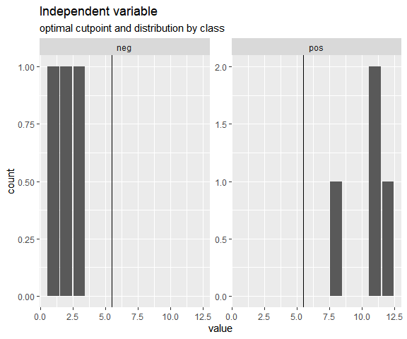

```r
plot_x(opt_cut)
```

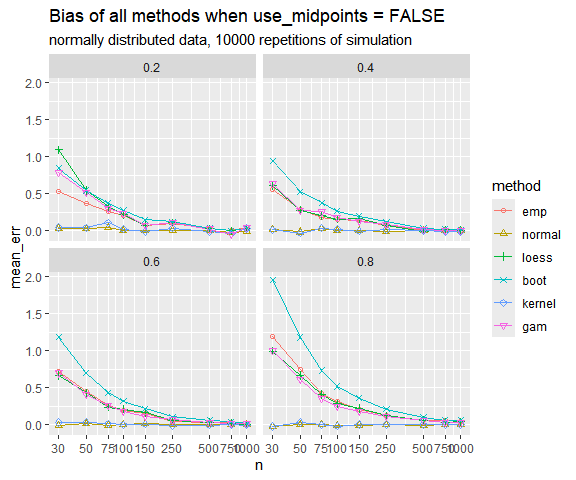